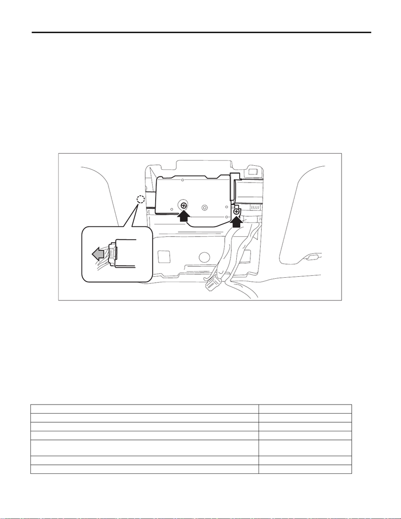

Sunroof Motor

SUNROOF/T-TOP/CONVERTIBLE TOP (SUNROOF)

6. Sunroof Motor

A: REMOVAL

1) Completely close the lid assembly - sunroof.

2) Disconnect the ground cable from battery. <Ref. to NT-5, BATTERY, NOTE, Note.>

NOTE:

For models other than STI model, disconnect the ground terminal from battery sensor.

3) Remove the light assembly - map. <Ref. to LI-60, REMOVAL, Spot Map Light.>

4) Remove the motor assembly - sunroof.

(1) Disconnect the harness connector.

(2) Remove the screws and remove the motor assembly - sunroof.

CAUTION:

When removing the motor assembly - sunroof, secure the cable assembly so that it does not move.

B: INSTALLATION

CAUTION:

When installing the motor assembly - sunroof, be careful not to move the cable assembly.

1) Install the motor assembly - sunroof.

2) Install the light assembly - map.

3) Connect the battery ground terminal. <Ref. to NT-5, BATTERY, NOTE, Note.>

NOTE:

For models other than STI model, connect the ground terminal to battery sensor.

4) Perform the initialize operation. <Ref. to SR-6, INITIALIZE OPERATION, OPERATION, Sunroof Control

System.>

5) Check the operation of sunroof by following the table below.

Operation Switch position

(1) Lid assembly - sunroof closes completely. Close

(2) Lid assembly - sunroof is tilted up to the top position. Tilt up

(3) Lid assembly - sunroof closes completely. Tilt down

(4) Lid assembly - sunroof opens 295 mm (11.61 in) away from completely closed

position.

Open

(5) Lid assembly - sunroof opens completely. Open

(6) Lid assembly - sunroof closes completely. Close

[figure not shown]

Sunroof Motor

SUNROOF/T-TOP/CONVERTIBLE TOP (SUNROOF)

C: INSPECTION

Check the auto-reverse mechanism.

CAUTION:

Do not place objects in the way to check the auto-reverse mechanism.

1) Open the lid assembly - sunroof.

2) Push the lid assembly - sunroof in the opening direction with a force of 110±10 N (11.2 kgf, 24.7 lbf±1.0

kgf, 2.2 lbf) during the auto-closing operation, and check whether the window auto-reverse mechanism func-

tions.

NOTE:

If the auto function is cancelled, perform the initialize operation. <Ref. to SR-6, INITIALIZE OPERATION,

OPERATION, Sunroof Control System.>